# Credit Card Fraud Detection Predictive Model

## Machine Learning

### Basic Comparision

[output not shown]

[output cut: 946 more lines]

[output not shown]

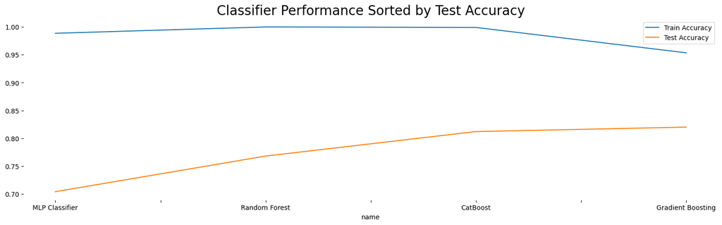

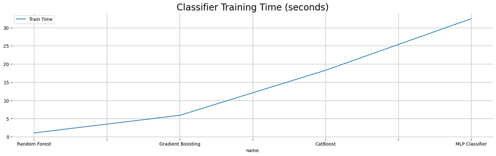

```python
# Comparision of several models by test accuracy and speed

import time
from sklearn.preprocessing import StandardScaler
from imblearn.over_sampling import RandomOverSampler
from sklearn.ensemble import RandomForestClassifier
from sklearn.pipeline import Pipeline
from sklearn.tree import DecisionTreeClassifier
from sklearn.ensemble import GradientBoostingClassifier
from sklearn.neural_network import MLPClassifier

features = cleaned_df.drop(['fraud_reported'], axis=1)
labels = cleaned_df['fraud_reported']

trained_models = [] #  keep track of all details for models we train

def train_model(model, features, labels):
  X = features
  y = labels.values

  X_train, X_test, y_train, y_test = train_test_split(X, y, random_state=42)

  oversample = RandomOverSampler(sampling_strategy=1)
  X_train, y_train = oversample.fit_resample(X_train, y_train)

  pipe = Pipeline([('scaler', StandardScaler()), ('clf', model["clf"])])
  start_time = time.time()
  pipe.fit(X_train, y_train)
  train_time = time.time() - start_time

  train_accuracy =  pipe.score(X_train, y_train)
  test_accuracy = pipe.score(X_test, y_test)
  model_details = {"name": model["name"], "train_accuracy":train_accuracy, "test_accuracy":test_accuracy, "train_time": train_time, "model": pipe}
  return model_details

models = [
          {"name": "Random Forest", "clf": RandomForestClassifier()},
          {"name": "Gradient Boosting", "clf": GradientBoostingClassifier()},
          {"name": "MLP Classifier", "clf": MLPClassifier(solver='adam', alpha=1e-1, hidden_layer_sizes=(10,10,5,2), max_iter=500, random_state=RANDOM_STATE)},
          {"name": "CatBoost", "clf":CatBoostClassifier(eval_metric='AUC', random_seed = RANDOM_STATE, od_type='Iter', od_wait=EARLY_STOP)},
          ]

for model in models:
  model_details = train_model(model, features, labels)
  trained_models.append(model_details)


# visualize accuracy and run time
#setup_plot()
model_df = pd.DataFrame(trained_models)
model_df.sort_values("test_accuracy", inplace=True)
ax = model_df[["train_accuracy","test_accuracy", "name"]].plot(kind="line", x="name", figsize=(19,5), title="Classifier Performance Sorted by Test Accuracy")
ax.legend(["Train Accuracy", "Test Accuracy"])
for p in ax.patches:
    ax.annotate( str( round(p.get_height(),3) ), (p.get_x() * 1.005, p.get_height() * 1.005))

ax.title.set_size(20)
plt.box(False)

model_df.sort_values("train_time", inplace=True)
ax= model_df[["train_time","name"]].plot(kind="line", x="name", figsize=(19,5), grid=True, title="Classifier Training Time (seconds)")
ax.title.set_size(20)
ax.legend(["Train Time"])
plt.box(False)
```

In the inital comparision over sampling was used as the dataset is somewhat imbalanced

```python
# Train test split

train_df, test_df = train_test_split(cleaned_df, test_size=TEST_SIZE, random_state=RANDOM_STATE, shuffle=True )
train_df, valid_df = train_test_split(train_df, test_size=VALID_SIZE, random_state=RANDOM_STATE, shuffle=True )
```

```python
# Target and Features

target = 'fraud_reported'
predictors = cleaned_df.drop(columns=['fraud_reported']).columns
```

### Random Forests

```python
# Creation of model
clf = RandomForestClassifier(random_state=RANDOM_STATE,
                             criterion=RFC_METRIC,
                             verbose=False)
```

```python
#Fit to data
clf.fit(train_df[predictors], train_df[target].values)
```

```
RandomForestClassifier(random_state=42, verbose=False)
```

```python
#Make predictions
preds = clf.predict(valid_df[predictors])
```

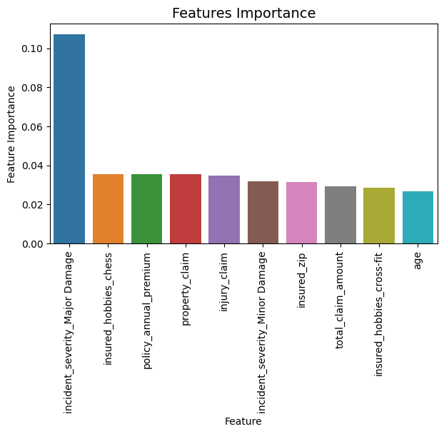

```python
tmp = pd.DataFrame({'Feature': predictors, 'Feature Importance': clf.feature_importances_})
tmp = tmp.sort_values(by='Feature Importance',ascending=False)

ten_most_important = tmp[0:10]
ten_most_important_df = pd.DataFrame(ten_most_important)

plt.figure(figsize = (7,4))
plt.title('Features Importance',fontsize=14)
s = sns.barplot(x='Feature',y='Feature Importance',data=ten_most_important_df)
s.set_xticklabels(s.get_xticklabels(),rotation=90)
plt.show()
```

```python
#ROC score
roc_auc_score(valid_df[target].values, preds)
```

```
0.5963949843260188
```

#### Hyperparameter Tuning

```python
from sklearn.model_selection import train_test_split, RandomizedSearchCV, RepeatedStratifiedKFold
from sklearn.ensemble import RandomForestClassifier
from sklearn.pipeline import Pipeline
from sklearn.preprocessing import StandardScaler
from scipy.stats import randint

# Separate features and labels
X = cleaned_df.drop(['fraud_reported'], axis=1)
y = cleaned_df['fraud_reported'].values

# Split the data into training and testing sets
X_train, X_test, y_train, y_test = train_test_split(X, y)

# Create the model
#rfc = RandomForestClassifier(random_state=RANDOM_STATE)

# Define the parameter space that will be searched over
param_distributions = {'clf__n_estimators': randint(1, 1000),
                       'clf__max_features': ['auto', 'sqrt'],
                       'clf__min_samples_leaf': randint(1, 5),
                       'clf__min_samples_split': randint(2, 10),
                       'clf__max_depth': randint(1, 100)}

rfc = Pipeline([('scaler', StandardScaler()), ('clf', RandomForestClassifier())])

# Create a searchCV object
search = RandomizedSearchCV(rfc,
                             n_iter=NUMBER_ITER,
                             scoring="roc_auc",
                             cv=RepeatedStratifiedKFold(n_splits=NUMBER_KFOLDS, n_repeats=NUMBER_REPEATS),
                             param_distributions=param_distributions,
                             random_state=0)

y_pred = search.fit(X_train, y_train).predict(X_test)

# Print the results
best_score = search.best_score_
print('Best ROC Score:', best_score)

best_params = search.best_params_
print('\nHyperparameter Tuning:', best_params)
```

```
Best ROC Score: 0.8440181977006616

Hyperparameter Tuning: {'clf__max_depth': 68, 'clf__max_features': 'sqrt', 'clf__min_samples_leaf': 2, 'clf__min_samples_split': 5, 'clf__n_estimators': 278}
```

For Random Forests, hyperparameter Tuning was run both with and without over sampling.

Higher AUC scores were obtained without the use of over sampling, but to aid the slight class imbalance RepeatedStratifiedKFold was used in the cross validation step.

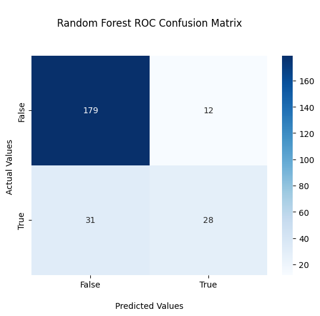

```python
#Generate the confusion matrix
cf_matrix = confusion_matrix(y_test, y_pred)

ax = sns.heatmap(cf_matrix, annot=True, cmap='Blues', fmt='.0f')

ax.set_title('\nRandom Forest ROC Confusion Matrix\n\n');
ax.set_xlabel('\nPredicted Values')
ax.set_ylabel('Actual Values ');

## Ticket labels - List must be in alphabetical order
ax.xaxis.set_ticklabels(['False','True'])
ax.yaxis.set_ticklabels(['False','True'])

## Display the visualization of the Confusion Matrix.
plt.show()
```

### Gradient Boosting

```python
clf = GradientBoostingClassifier(
                             random_state=RANDOM_STATE,
                             criterion=GBC_METRIC,
                             verbose=False)
```

```python
clf.fit(train_df[predictors], train_df[target].values)
```

```
GradientBoostingClassifier(criterion='squared_error', random_state=42,
                           verbose=False)
```

```python
preds = clf.predict(valid_df[predictors])
```

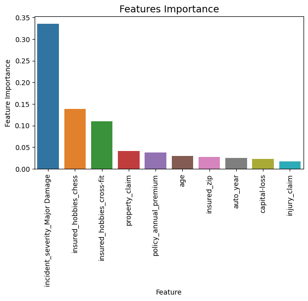

```python
tmp = pd.DataFrame({'Feature': predictors, 'Feature Importance': clf.feature_importances_})
tmp = tmp.sort_values(by='Feature Importance',ascending=False)

ten_most_important = tmp[0:10]
ten_most_important_df = pd.DataFrame(ten_most_important)


plt.figure(figsize = (7,4))
plt.title('Features Importance',fontsize=14)
s = sns.barplot(x='Feature',y='Feature Importance',data=ten_most_important_df)
s.set_xticklabels(s.get_xticklabels(),rotation=90)
plt.show()
```

```python
roc_auc_score(valid_df[target].values, preds)
```

```
0.7621473354231976
```

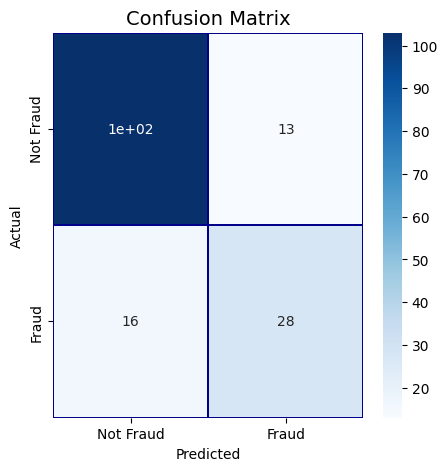

```python
cm = pd.crosstab(valid_df[target].values, preds, rownames=['Actual'], colnames=['Predicted'])
fig, (ax1) = plt.subplots(ncols=1, figsize=(5,5))
sns.heatmap(cm,
            xticklabels=['Not Fraud', 'Fraud'],
            yticklabels=['Not Fraud', 'Fraud'],
            annot=True,ax=ax1,
            linewidths=.2,linecolor="Darkblue", cmap="Blues")
plt.title('Confusion Matrix', fontsize=14)
plt.show()
```

#### Hyperparameter Tuning

```python
# Separate features and labels
X = cleaned_df.drop(['fraud_reported'], axis=1)
y = cleaned_df['fraud_reported'].values

# Split the data into training and testing sets
X_train, X_test, y_train, y_test = train_test_split(X, y)

# Define the parameter space that will be searched over
param_distributions = {'clf__n_estimators': randint(1, 1000),
                       'clf__max_features': ['auto', 'sqrt'],
                       'clf__min_samples_leaf': randint(1, 5),
                       'clf__min_samples_split': randint(2, 10),
                       'clf__max_depth': randint(1, 100)}

#Create a pipeline
gbc = Pipeline([('scaler', StandardScaler()), ('clf', GradientBoostingClassifier())])

# Create a searchCV object
search = RandomizedSearchCV(gbc,
                             n_iter=NUMBER_ITER,
                             scoring="roc_auc",
                             cv=RepeatedStratifiedKFold(n_splits=NUMBER_KFOLDS, n_repeats=NUMBER_REPEATS),
                             param_distributions=param_distributions,
                             random_state=0)

y_pred = search.fit(X_train, y_train).predict(X_test)

# Print the results
best_score = search.best_score_
print('Best ROC Score:', best_score)

best_params = search.best_params_
print('\nHyperparameter Tuning:', best_params)
```

```
Best ROC Score: 0.8754595905911694

Hyperparameter Tuning: {'clf__max_depth': 13, 'clf__max_features': 'auto', 'clf__min_samples_leaf': 2, 'clf__min_samples_split': 8, 'clf__n_estimators': 552}
```

For Gradient Boosting, hyperparameter Tuning was run both with and without over sampling.

Higher AUC scores were obtained without the use of over sampling, but to aid the slight class imbalance RepeatedStratifiedKFold was used in the cross validation step.

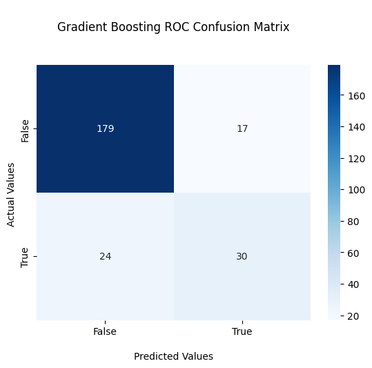

```python
#Generate the confusion matrix
cf_matrix = confusion_matrix(y_test, y_pred)

ax = sns.heatmap(cf_matrix, annot=True, cmap='Blues', fmt='.0f')

ax.set_title('\nGradient Boosting ROC Confusion Matrix\n\n');
ax.set_xlabel('\nPredicted Values')
ax.set_ylabel('Actual Values ');

## Ticket labels - List must be in alphabetical order
ax.xaxis.set_ticklabels(['False','True'])
ax.yaxis.set_ticklabels(['False','True'])

## Display the visualization of the Confusion Matrix.
plt.show()
```

### Custom Loss Function and SHAP analysis

After hyperparameter tuning Random Forests returned a Best ROC Score: 0.844

Therefore Gradient Boosting was selected for the custom scorer hyperparameter tuning

```
Best Custom Score: 0.620022095187253

Hyperparameter Tuning: {'clf__max_depth': 45, 'clf__max_features': 'sqrt', 'clf__min_samples_leaf': 2, 'clf__min_samples_split': 2, 'clf__n_estimators': 836}
```

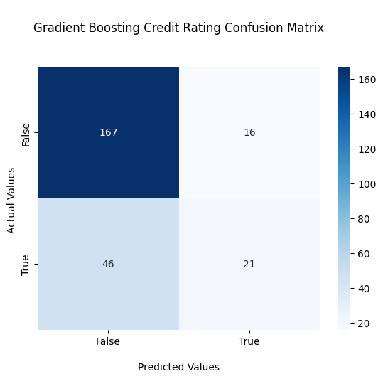

```
time taken:  79.0
```

```python
from sklearn.metrics import make_scorer

time1 = time.time()

# Separate features and labels
data = cleaned_df.drop(['fraud_reported'], axis=1)
labels = cleaned_df['fraud_reported']

X_train, X_test, y_train, y_test = train_test_split(data, labels, random_state=42)

#undersample = RandomUnderSampler(sampling_strategy=1)
#X_train, y_train = undersample.fit_resample(X_train, y_train)

def my_custom_loss_func(X_train, y_train):
    CM = confusion_matrix(y_test, y_pred)
    CM = CM.astype('float') / CM.sum(axis=1)[:, np.newaxis]
    FN = CM[1][0]
    FP = CM[0][1]
    credit_score = (((-10*FN) + (-1*FP))/11)
    return credit_score

my_scorer = make_scorer(my_custom_loss_func, greater_is_better=False)

gbc = Pipeline([('scaler', StandardScaler()), ('clf', GradientBoostingClassifier())])

param_grid = {'clf__n_estimators': randint(1, 1000),
                         'clf__max_features': ['auto', 'sqrt'],
                         'clf__min_samples_leaf': randint(1, 5),
                         'clf__min_samples_split': randint(2, 10),
                         'clf__max_depth': randint(1, 100)}

search = RandomizedSearchCV(gbc, n_iter=NUMBER_ITER, scoring=my_scorer, cv = RepeatedStratifiedKFold(n_splits=NUMBER_KFOLDS, n_repeats=NUMBER_REPEATS),
                              param_distributions=param_grid, random_state=0)

y_pred = search.fit(X_train, y_train).predict(X_test)

Best_Score = search.best_score_
print('Best Custom Score:', Best_Score)
Best_Params = search.best_params_
print('\nHyperparameter Tuning:', Best_Params)

#Generate the confusion matrix
cf_matrix = confusion_matrix(y_test, y_pred)

ax = sns.heatmap(cf_matrix, annot=True, cmap='Blues', fmt='.0f')

ax.set_title('\nGradient Boosting Credit Rating Confusion Matrix\n\n');
ax.set_xlabel('\nPredicted Values')
ax.set_ylabel('Actual Values ');

## Ticket labels - List must be in alphabetical order
ax.xaxis.set_ticklabels(['False','True'])
ax.yaxis.set_ticklabels(['False','True'])

## Display the visualization of the Confusion Matrix.
plt.show()

time2 = np.round(time.time() - time1,0)
print("\ntime taken: ", time2)
```

Why do we need a custom loss function?

Both false positive and false negative results are generated from the machine learning calculations.

In the case of false positives this results in extra work for the business double checking claims.

False negatives (I.e Customers that are deliberately attempting fraud) are what we must reduce at the expense of higher false positives.

Hence with a custom loss function we can penalise false negatives, I have chosen to make each false negative ten times the cost of a false positive.

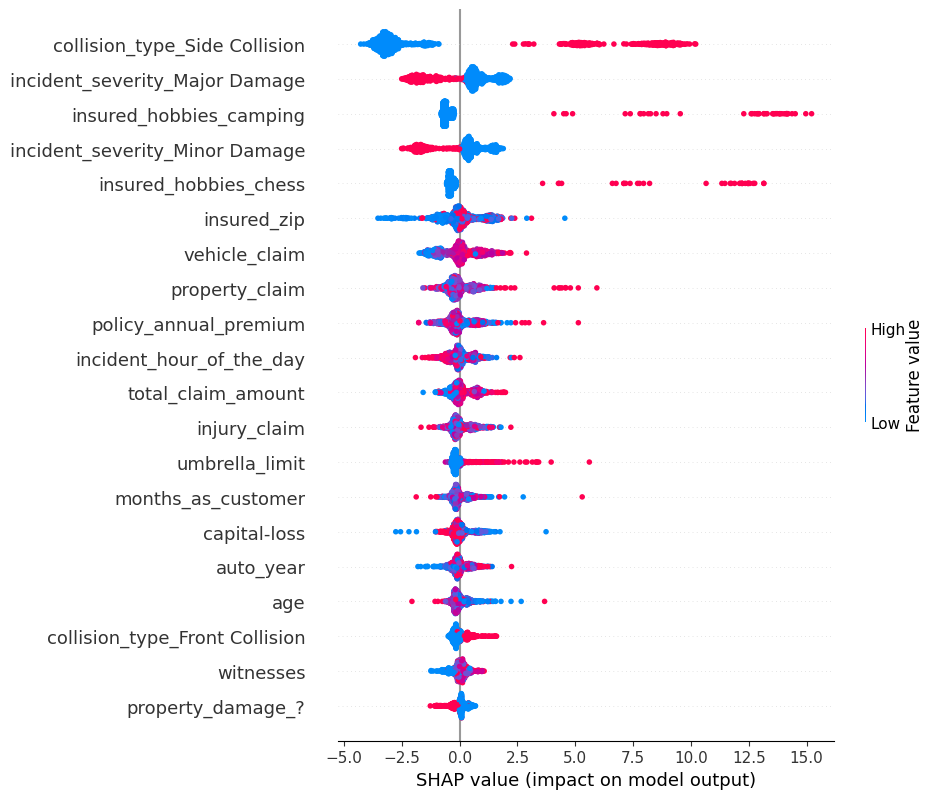

```python
# Use of SHAP to show global features and their respective devation from the mean

import shap

gbc = GradientBoostingClassifier(random_state=RANDOM_STATE, max_depth=45, max_features='sqrt', min_samples_leaf=2, min_samples_split=2, n_estimators=836)

X = np.array(cleaned_df.drop(['fraud_reported'], axis=1))
y = cleaned_df['fraud_reported'].values

feature_list = list(cleaned_df.columns)

gbc.fit(X, y);

explainer = shap.Explainer(gbc)
shap_values = explainer(X)

shap.summary_plot(shap_values, X, feature_list)
```